# Introduction to R and Rstudio

Session - Packages

Zoë Turner

## Package locations

### CRAN repository

[Comprehensive R Archive Network](https://cran.r-project.org/web/packages/)

19,291 packages (March 2023), free and structurally peer reviewed

### GitHub

Many useful packages in development or subject to a lot of change are not on CRAN and are available through GitHub including [{NHSRtheme}](https://github.com/nhs-r-community/NHSRtheme). These won’t be peer reviewed.

### ROpenSci

ROpenSci offer a peer reviewed ecosystem of R packages through GitHub including UKHSA’s [{fingertipsR}](https://github.com/ropensci/fingertipsR)

## Packages

Quotations in R can be either double or single quotes but cannot be mixed or omitted:

```r
# either
install.packages("tidyverse")

# or
install.packages('tidyverse')
```

or use the RStudio wizard (only for published CRAN packages)

[figure not shown]

# Loading package

This needed for every new session/script and is often at the top

```r
library(tidyverse)
```

Can be loaded from the packages panel and code appears in the Console

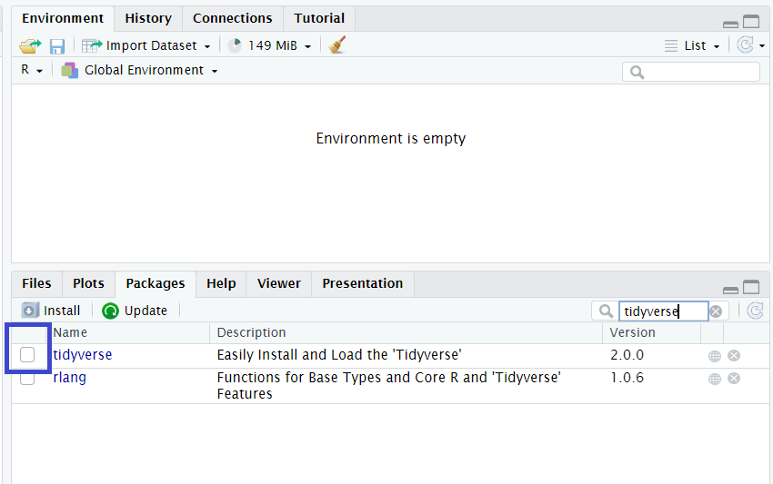

## {tidyverse}

Curly brackets around a {package} is used in text as many packages have “real names”

[figure not shown]

## What is the {tidyverse}?

The [tidyverse package](https://www.tidyverse.org/) collects (some of) the most popular  
R packages into one.

Also refers to a coding style in R.

## {tidyverse} debate

Should you use {tidyverse} when many of the packages are redundant?

Clashes occur with the packages which you are notified about, but not with those outside the package

```r
── Attaching core tidyverse packages ────────────────────────────────────────────────────────────── tidyverse 2.0.0 ──
✔ dplyr     1.1.0     ✔ readr     2.1.4
✔ forcats   1.0.0     ✔ stringr   1.5.0
✔ ggplot2   3.4.1     ✔ tibble    3.1.8
✔ lubridate 1.9.2     ✔ tidyr     1.3.0
✔ purrr     1.0.1
── Conflicts ──────────────────────────────────────────────────────────────────────────────── tidyverse_conflicts() ──
✖ dplyr::filter() masks stats::filter()
✖ dplyr::lag()    masks stats::lag()
ℹ Use the conflicted package to force all conflicts to become errors
```

## Errors, warnings & notifications

Warnings - not errors, just information on versions (from an older system)

```
Warning messages:
1: package ‘tidyverse’ was built under R version 4.0.4
2: package ‘tidyr’ was built under R version 4.0.3
3: package ‘readr’ was built under R version 4.0.3
4: package ‘purrr’ was built under R version 4.0.3
5: package ‘dplyr’ was built under R version 4.0.3
6: package ‘stringr’ was built under R version 4.0.3
```

Don’t rely upon colour changes as all three are orange in the console!